# Data_Mining_2019-Get_Started

Max Leodolter

28 10 2019

# Mobility Task

For the lecture Data Mining, winter term 2019/2020. This document provides some help to load, preprocess and handle the data in R. If you’re not an R user, you still should use this document to gain information about the data format.

### Setup

Install some packages:

```r
p <- c("data.table", "lubridate", "leaflet", "ggplot2","tidyr","kableExtra", "jmotif")

ip <- installed.packages()[, 1]
for( pp in p){
  if(!pp %in% ip) install.packages(pp)
}

library(data.table) # for fast csv reading
library(lubridate) # for time stamp handling
library(leaflet) # for map plotting
library(ggplot2) # for nice plots
library(tidyr) # for data manipulations
library(kableExtra) # for nice HTML tables
library(jmotif) # for PAA
```

Save the data chunk somewhere locally on your machine, **path_data**.

```r
# The directory where your data chunk is saved. Adjust this variable.
path_data <- "C:/Users/leodolterm/Data/Datamining19/cgt-stud-2019"

# The directory name for one trip:
# trip_dir <- "4_6_2019-10-22T065326.588"
trip_dir <- "5_5_2019-10-21T154114.648"
```

The data is stored as one driectory per trip. The name of the directory is userID_dataChunkID_timestamp. Per trip you will find several .csv files in the trip directory. In the following we will discuss the most important for this task. Feel free to take a look in the others as well.

### Markers

In the markers file you find meta information about the trip and the annotations during the trip. The markers file has “;” as seperation, all the other files “,”.

```r
# the markers file doesnt't fulfill standard csv file conventions, so you need "fill = TRUE"

markers <- fread(file.path(path_data, trip_dir, "markers.csv"), sep = ";", fill = TRUE)

#
# kable(cbind(mtcars, mtcars)) %>%
#   add_header_above(c("a" = 5, "b" = 18)) %>%
#   kable_styling() %>%
#   scroll_box(width = "100%", height = "200px")

kable(markers) %>%
  kable_styling(font_size = 9) %>%
  scroll_box(width = "100%", height = "200px")
```

V1

V2

V3

V4

V5

V6

V7

V8

V9

V10

time

key

value

NA

NA

2019-10-21T15:41:14.648Z

no_key

START

NA

NA

2019-10-21T15:41:14.648Z

MODEL

Xiaomi Mi A2 Lite

NA

NA

2019-10-21T15:41:14.648Z

TOKEN

max2:06F12BCF3EEA6EF12041DF9583102FF1C0841260D01F405D4C8A65ECD713DF7E

NA

NA

2019-10-21T15:41:14.675Z

CGT_APP_VERSION

1.0.0

NA

NA

2019-10-21T15:41:14.676Z

CGT_META

2019-10-21T15:41:14Z

true

Other

NA

NA

2019-10-21T15:41:17.198Z

CGT_MODE_CHANGED

2019-10-21T15:41:14Z

WALK

16.425544

48.2687195

NA

NA

2019-10-21T15:47:08.382Z

CGT_MODE_CHANGED

2019-10-21T15:47:01Z

TRAIN

16.42137819

48.27116928

SiemensstraÃŸe

224311104

NA

2019-10-21T15:56:10.821Z

CGT_MODE_CHANGED

2019-10-21T15:56:05Z

WALK

16.38612387

48.24235877

Wien Handelskai

2879956274

NA

2019-10-21T15:57:21.135Z

CGT_MODE_CHANGED

2019-10-21T15:57:13Z

METRO

16.38618572

48.24212106

Wien Handelskai

2879956274

NA

2019-10-21T16:05:01.328Z

CGT_MODE_CHANGED

2019-10-21T16:04:56Z

WALK

16.34954123

48.22596778

Währinger Straße-Volksoper

4233524092

NA

2019-10-21T16:08:03.654Z

CGT_MODE_CHANGED

2019-10-21T16:07:56Z

TRAM

16.34955766

48.22476036

Währinger Straße-Volksoper

2309799473

NA

2019-10-21T16:12:22.649Z

CGT_MODE_CHANGED

2019-10-21T16:12:18Z

WALK

16.35904704

48.21739847

SchwarzspanierstraÃŸe

2291874222

NA

2019-10-21T16:13:09.270Z

CGT_MODE_CHANGED

2019-10-21T16:13:06Z

WALK

16.35851319

48.21782252

NA

NA

2019-10-21T16:13:09.319Z

no_key

STOP

NA

NA

```r
#--- Who recorded the trip?
strsplit(markers$V3[markers$V2 == "TOKEN"], ":")[[1]][1]
```

```
## [1] "max2"
```

```r
#--- Which modes were annotated?
markers[markers$V2 == "CGT_MODE_CHANGED", V4]
```

```
## [1] "WALK"  "TRAIN" "WALK"  "METRO" "WALK"  "TRAM"  "WALK"  "WALK"
```

```r
#--- When did the mode changes take place?
# To be precise:
# Der Zeitstempel in der ersten Spalte des markers.csv file ist der Zeitpunkt wenn die Zeile geschrieben wird.
# Beim marker CGT_MODE_CHANGED ist das unmittelbar nachdem man in der APP CONFIRM drückt.
#
# Der Zeitstempel in der dritten Spalte des markers.csv file ist der Zeitpunkt wenn der Prozess, der das Schreiben des Markers verursacht, startet.
# Beim marker CGT_MODE_CHANGED ist das der Zeitpunkt wenn man auf in der App CHANGE MODE drückt.
markers[markers$V2 == "CGT_MODE_CHANGED", V3]
```

```
## [1] "2019-10-21T15:41:14Z" "2019-10-21T15:47:01Z" "2019-10-21T15:56:05Z"
## [4] "2019-10-21T15:57:13Z" "2019-10-21T16:04:56Z" "2019-10-21T16:07:56Z"
## [7] "2019-10-21T16:12:18Z" "2019-10-21T16:13:06Z"
```

```r
# die Timestamps sind im ISO 8601 Format (mit Zeitzone UTC, deswegen das Z am Ende).
t0 <- markers[markers$V2 == "CGT_MODE_CHANGED", V3]

# compensate the time zone of the timestamp
ymd_hms(t0) # no time zone
```

```
## [1] "2019-10-21 15:41:14 UTC" "2019-10-21 15:47:01 UTC"
## [3] "2019-10-21 15:56:05 UTC" "2019-10-21 15:57:13 UTC"
## [5] "2019-10-21 16:04:56 UTC" "2019-10-21 16:07:56 UTC"
## [7] "2019-10-21 16:12:18 UTC" "2019-10-21 16:13:06 UTC"
```

```r
with_tz(ymd_hms(t0)) #with time zone
```

```
## [1] "2019-10-21 17:41:14 CEST" "2019-10-21 17:47:01 CEST"
## [3] "2019-10-21 17:56:05 CEST" "2019-10-21 17:57:13 CEST"
## [5] "2019-10-21 18:04:56 CEST" "2019-10-21 18:07:56 CEST"
## [7] "2019-10-21 18:12:18 CEST" "2019-10-21 18:13:06 CEST"
```

```r
#--- Where did the mode changes take place?
markers[markers$V2 == "CGT_MODE_CHANGED", list(V5, V6)] #longitude, latitude
```

```
##             V5          V6
## 1:   16.425544  48.2687195
## 2: 16.42137819 48.27116928
## 3: 16.38612387 48.24235877
## 4: 16.38618572 48.24212106
## 5: 16.34954123 48.22596778
## 6: 16.34955766 48.22476036
## 7: 16.35904704 48.21739847
## 8: 16.35851319 48.21782252
```

```r
#--- How long is the trip?
t01 <- markers[markers$V3 %in% c("START", "STOP"), V1] %>% ymd_hms() %>% with_tz()
difftime(t01[2] , t01[1])
```

```
## Time difference of 31.91118 mins
```

### Acceleration

```r
acc <- fread(file.path(path_data, trip_dir, "acceleration.csv"))
acc$time <- with_tz(ymd_hms(acc$time))
head(acc)
```

```
##                   time        x        y        z
## 1: 2019-10-21 17:41:14 1.781921 2.755371 4.566742
## 2: 2019-10-21 17:41:14 1.781921 2.755371 4.566742
## 3: 2019-10-21 17:41:14 1.781921 2.755371 4.566742
## 4: 2019-10-21 17:41:14 1.781921 2.755371 4.566742
## 5: 2019-10-21 17:41:14 1.781921 2.755371 4.566742
## 6: 2019-10-21 17:41:14 2.384903 1.530243 7.655869
```

```r
dim(acc)
```

```
## [1] 199972      4
```

```r
# acceleration is sampled with a sampling rate of ~100 Hz.
# get the time stamp as numeric including the milliseconds:
acc$time_ms <- as.numeric(seconds(acc$time) * 1000)

# interpolate the data to be equidistant at the rate of 10 Hz
t0 <- head(acc$time_ms, 1)
t1 <- tail(acc$time_ms, 1)
t1-t0
```

```
## [1] 1914654
```

```r
t_equi <- seq(t0, t1, by = 10) # 100 Hz
# PAA_NUM <- length(t_equi)/20 # aggregate 20 values to 1 => 5Hz
PAA_NUM <- length(t_equi)/10 # aggregate 10 values to 1 => 10Hz

# define help function for equidistant sampling and piecewise aggregate approximation
foo <- function(x){
  approx(x = acc$time_ms, y = x, xout = t_equi)$y %>%
    paa(., paa_num = PAA_NUM)
}

acc_equi <- data.frame(time_ms = paa(t_equi, PAA_NUM),
                       x = foo(acc$x),
                       y = foo(acc$y),
                       z = foo(acc$z))

head(acc_equi)
```

```
##        time_ms         x         y         z
## 1 1.571672e+12 1.9386493 2.4603057  6.695964
## 2 1.571672e+12 1.8815352 2.3317181 11.224669
## 3 1.571672e+12 1.6862944 1.8513112 12.054310
## 4 1.571672e+12 1.0430609 0.6309750  8.641874
## 5 1.571672e+12 1.1456279 0.7104159  6.741037
## 6 1.571672e+12 0.5714482 1.4827712  8.679093
```

```r
dim(acc_equi)
```

```
## [1] 19146     4
```

Plot the acceleration signal:

```r
dfp <- gather(acc_equi, ... = c("x", "y", "z"))
dfp$time <-  as.POSIXct(acc_equi$time_ms/1000, origin = "1970-01-01", tz = "UTC")
dim(dfp)
```

```
## [1] 57438     4
```

```r
head(dfp)
```

```
##        time_ms key     value                time
## 1 1.571672e+12   x 1.9386493 2019-10-21 15:41:14
## 2 1.571672e+12   x 1.8815352 2019-10-21 15:41:14
## 3 1.571672e+12   x 1.6862944 2019-10-21 15:41:14
## 4 1.571672e+12   x 1.0430609 2019-10-21 15:41:15
## 5 1.571672e+12   x 1.1456279 2019-10-21 15:41:15
## 6 1.571672e+12   x 0.5714482 2019-10-21 15:41:15
```

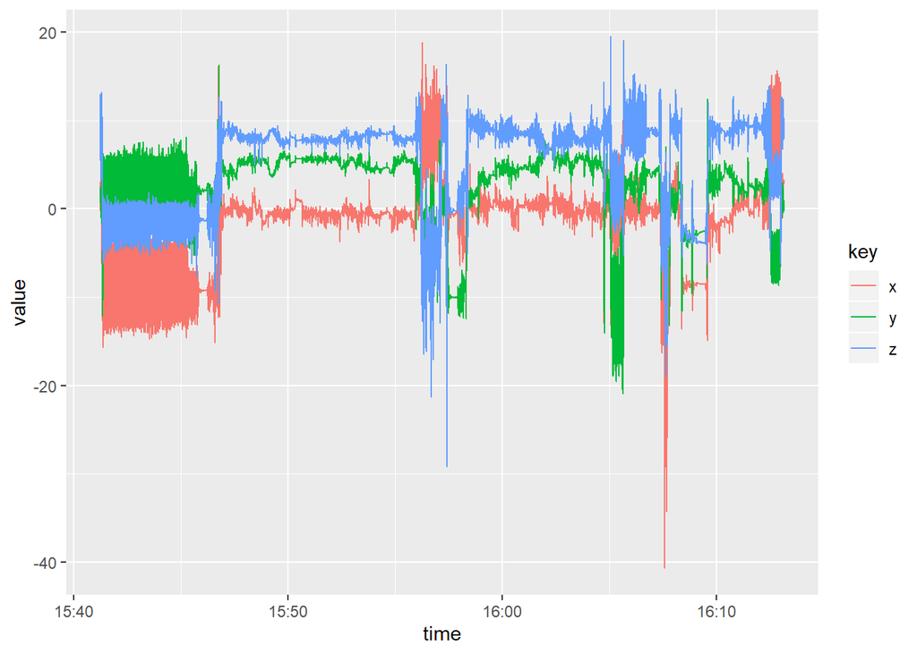

```r
ggplot(dfp) + geom_line(aes(x = time, y = value, group = key, col = key))
```

Get the magnitude of the signal by calculating the n2-norm:

```r
n2 <- data.frame(time = as.POSIXct(acc_equi$time_ms/1000, origin = "1970-01-01", tz = "UTC"),
                value = apply(acc_equi, 1, function(a){sqrt(sum(a[2:4]^2))}))
dim(n2)
```

```
## [1] 19146     2
```

```r
gg1 <- ggplot(n2) + geom_line(aes(x = time, y = value))
```

Add the annotations from the App:

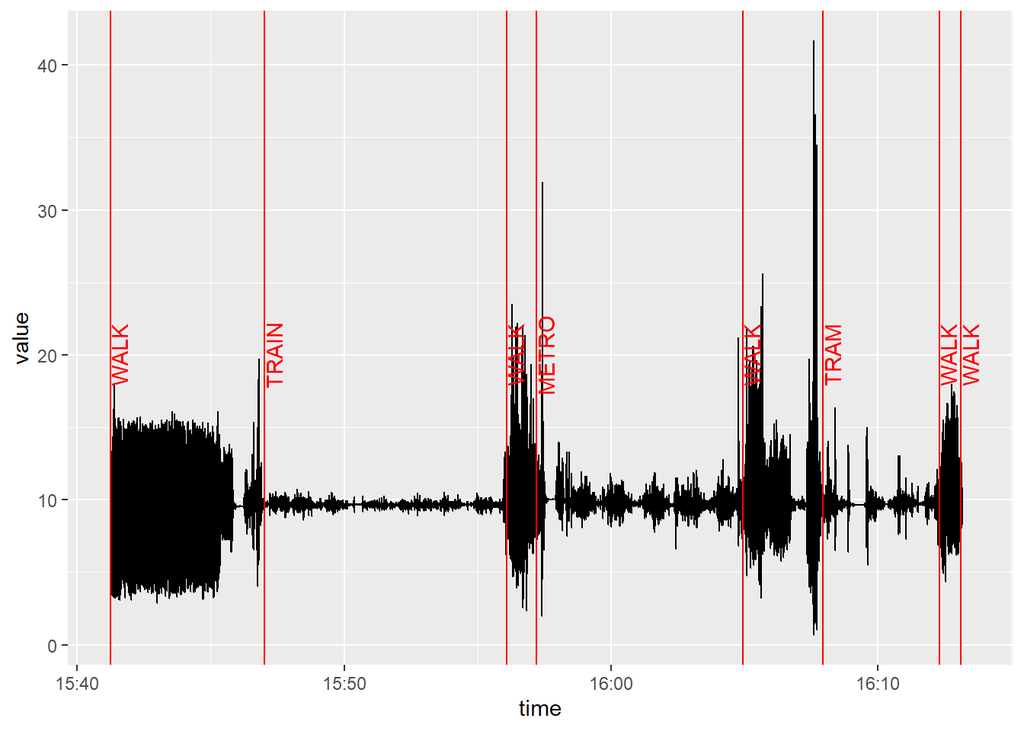

```r
changes <- markers[V2 == "CGT_MODE_CHANGED", list(time = with_tz(ymd_hms(V3)), mode = V4)]
gg1 + geom_vline(data = changes, aes(xintercept = time), col = "red")+
  geom_text(data = changes, aes(x = time + 20, y = 20, label = mode, angle = 90), col = "red")
```

### Positions

```r
pos <- fread(file.path(path_data, trip_dir, "positions.csv"))

kable(pos[1:20, ]) %>%
  kable_styling(font_size = 9) %>%
  scroll_box(width = "100%", height = "200px")
```

| time | latitude | longitude | altitude | accuracy | hdop | sats | location_source | speed | bearing |
| --- | --- | --- | --- | --- | --- | --- | --- | --- | --- |
| 2019-10-21T15:41:15.868Z | 48.26872 | 16.42554 | 208.3000 | 50.163 | NaN | 0 | 0 | 0.00 | 0.0 |
| 2019-10-21T15:41:19.036Z | 48.26877 | 16.42548 | 207.5262 | 19.296 | NaN | 0 | 1 | 1.09 | 304.2 |
| 2019-10-21T15:41:20.035Z | 48.26882 | 16.42535 | 206.8486 | 24.656 | NaN | 0 | 1 | 1.79 | 304.8 |
| 2019-10-21T15:41:21.091Z | 48.26873 | 16.42530 | 218.1122 | 5.360 | NaN | 0 | 1 | 1.38 | 312.4 |
| 2019-10-21T15:41:21.822Z | 48.26873 | 16.42526 | 215.7861 | 10.720 | NaN | 0 | 1 | 1.46 | 328.6 |
| 2019-10-21T15:41:22.820Z | 48.26873 | 16.42524 | 216.3386 | 8.576 | NaN | 0 | 1 | 1.49 | 305.3 |
| 2019-10-21T15:41:23.827Z | 48.26874 | 16.42524 | 217.4255 | 8.576 | NaN | 0 | 1 | 1.78 | 328.8 |
| 2019-10-21T15:41:24.830Z | 48.26875 | 16.42523 | 219.0487 | 8.576 | NaN | 0 | 1 | 1.49 | 353.4 |
| 2019-10-21T15:41:25.826Z | 48.26877 | 16.42521 | 219.3137 | 7.504 | NaN | 0 | 1 | 1.49 | 317.8 |
| 2019-10-21T15:41:26.827Z | 48.26879 | 16.42521 | 218.1861 | 6.432 | NaN | 0 | 1 | 1.47 | 354.2 |
| 2019-10-21T15:41:27.827Z | 48.26880 | 16.42521 | 218.9042 | 6.432 | NaN | 0 | 1 | 1.48 | 352.9 |
| 2019-10-21T15:41:28.830Z | 48.26882 | 16.42522 | 217.8436 | 7.504 | NaN | 0 | 1 | 1.47 | 2.4 |
| 2019-10-21T15:41:29.822Z | 48.26883 | 16.42521 | 218.5383 | 6.432 | NaN | 0 | 1 | 1.48 | 341.0 |
| 2019-10-21T15:41:30.831Z | 48.26884 | 16.42520 | 218.1378 | 6.432 | NaN | 0 | 1 | 1.48 | 325.7 |
| 2019-10-21T15:41:31.827Z | 48.26885 | 16.42519 | 218.1075 | 6.432 | NaN | 0 | 1 | 1.50 | 315.5 |
| 2019-10-21T15:41:32.834Z | 48.26886 | 16.42517 | 217.5142 | 5.360 | NaN | 0 | 1 | 1.51 | 309.8 |
| 2019-10-21T15:41:33.827Z | 48.26887 | 16.42516 | 216.8934 | 5.360 | NaN | 0 | 1 | 1.51 | 316.7 |
| 2019-10-21T15:41:34.832Z | 48.26888 | 16.42515 | 216.1592 | 5.360 | NaN | 0 | 1 | 1.51 | 324.7 |
| 2019-10-21T15:41:35.840Z | 48.26889 | 16.42514 | 216.1381 | 5.360 | NaN | 0 | 1 | 1.52 | 327.5 |
| 2019-10-21T15:41:36.832Z | 48.26890 | 16.42513 | 211.9218 | 5.360 | NaN | 0 | 1 | 1.53 | 324.5 |

```r
#concentrate on GPS data by filtering the location source
pos <- pos[location_source == 1]

# define a small function for plotting a trip:
view_trip <- function(x){
  # x ...  the csv input as data.table
  dfp <- x[, list(longitude, latitude)]
  colnames(dfp) <- c("lon", "lat")#, "k")
  TILES <- c("osm", "Stamen.Watercolor", "Stamen.TonerHybrid",
             "Stamen.Terrain", "Esri.WorldImagery")
  TILE <- TILES[4]

  lplot0 <- leaflet("map") %>%
    addCircleMarkers(data = dfp, radius = 3, opacity = 1) %>% #, color = ~pal(ca)) %>%
    addProviderTiles(TILE)
  lplot0
}

view_trip(pos)
```

[interactive chart not shown]